# Geographic RDD: a simple example

Giacomo Lemoli

13/4/2023

# Working example

Albertus and Popescu (QJPS 2020) study the effects of land reform on economic and social development. They use Peru’s land reform of 1970. For identification, they use the fact that in some areas the reform was more intense.

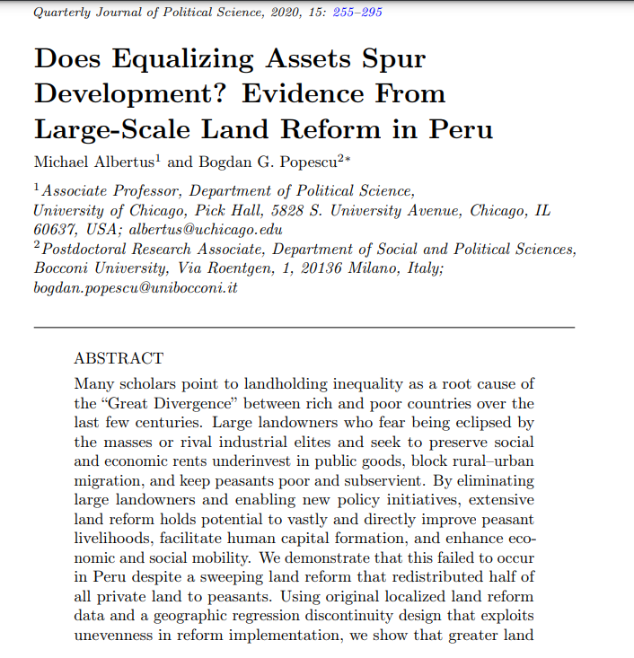

We work with their data (available [here](https://www.nowpublishers.com/article/Details/QJPS-19033) ).

Our goal with this example:

- Apply RDD tools to geographic settings
- Have a look at how to use basic geographic data

First, set the directory and import the packages to be used.

`R` has several packages to work with geo-data. We will use with the package `sf`. The great advantage of `sf` is that its objects are also of class data.frame, which allows to integrate geographic computations and standard data manipulation with base R or `tidyverse`.

Another popular package to check is `sp`.

```r
## Set directory
dirs <- c("C:/Users/gl1759/Dropbox/NYU/TA Work/Quant 2 Spring 2022/Replication packages/Albertus & Popescu QJPS 2020",
               "C:/Users/giaco/Dropbox/NYU/TA Work/Quant 2 Spring 2022/Replication packages/Albertus & Popescu QJPS 2020")
setwd(Find(dir.exists, dirs))

## Packages
library(sf)
library(tidyverse)
library(fixest)
library(ggpubr)
library(rdrobust)
```

# Load geographic data

Their dataset contains shapefiles with several layers (polygons and lines). We use only a selection of them.

```r
## Import the shapefiles
shp_data <- paste0(getwd(), "/replication_package/Data/map_data.gdb")

## Let's have a look at the layers
(st_layers(dsn=shp_data))
```

```
## Driver: OpenFileGDB
## Available layers:
##                layer_name     geometry_type features fields
## 1               agrozone3     Multi Polygon        1      3
## 2               agrozones     Multi Polygon       13      3
## 3       department_ancash     Multi Polygon        1      3
## 4    department_cajamarca     Multi Polygon        1      3
## 5      department_huanuco     Multi Polygon        1      3
## 6  department_la_libertad     Multi Polygon        1      3
## 7   department_san_martin     Multi Polygon        1      3
## 8             departments     Multi Polygon       24      3
## 9          districts_1975     Multi Polygon     1676      7
## 10          key_districts     Multi Polygon        6      7
## 11        core_periph_brd Multi Line String        1      2
## 12      inside_zone3_core     Multi Polygon        1      2
```

```r
## Districts
ds <- st_read(dsn=shp_data, layer="districts_1975")
## Broad reform area
az3 <- st_read(dsn=shp_data, layer="agrozone3")
## Core area boundary
border <- st_read(dsn=shp_data, layer="core_periph_brd")
```

The first step after we load geographic data is to check that the Coordinate Reference System is the same across datasets (otherwise projections are different and the overlap of different units will be incorrect)

```r
## Check CRS is the same
lapply(list(ds, az3), function(x) st_crs(x)==st_crs(border))
```

```
## [[1]]
## [1] TRUE
##
## [[2]]
## [1] TRUE
```

# Basic visualization

The simple and flexible `sf` environment allows to draw maps of our data in a straightforward way.

We start by drawing a map of our population: Peruvian districts. We overlay to this map our sample of interest (Agrarian reform zone 3) and the treatment assignment (the border of the core reform area).

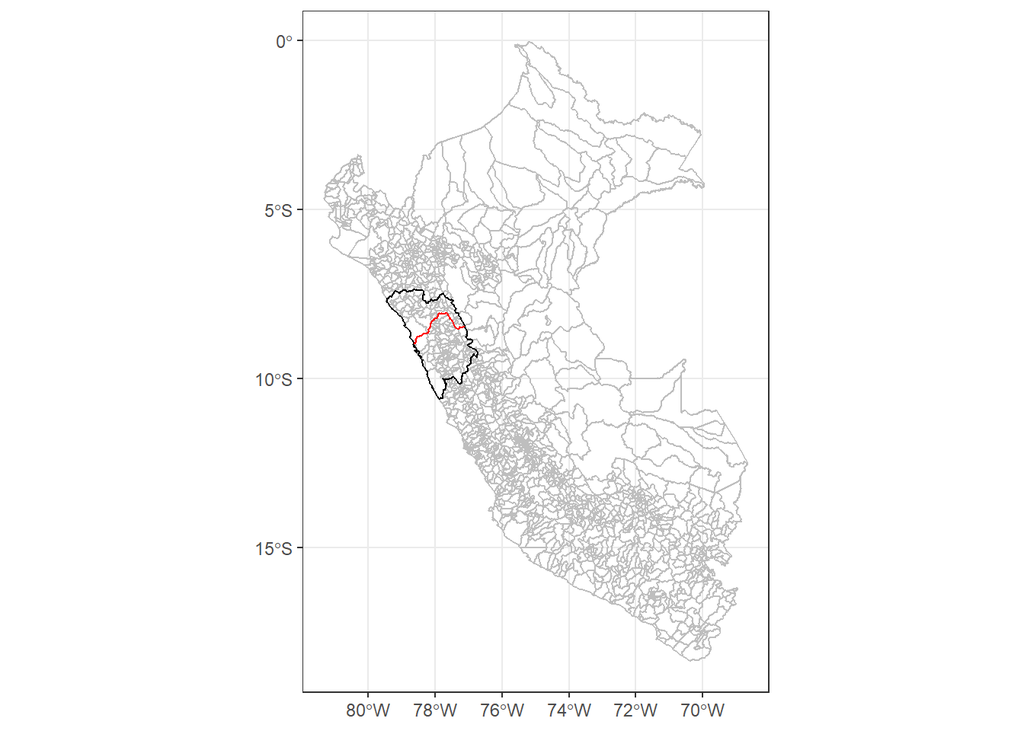

```r
## Plot of the analysis sample + treatment assignment
map <- ggplot() +
  geom_sf(data=ds, color="grey", fill=NA) +
  geom_sf(data=az3, color="black", fill=NA) +
  geom_sf(data=border, color="red") +
  theme_bw()
map
```

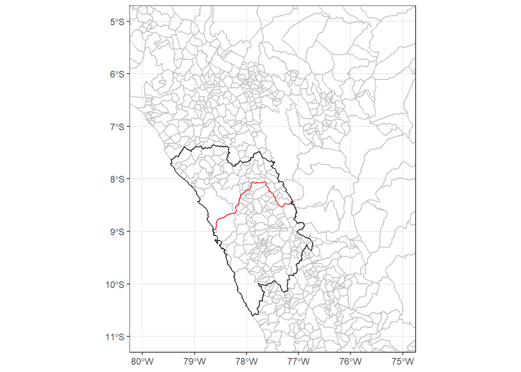

```r
## Zoom in
map <- map + coord_sf(xlim=c(-80, -75), ylim=c(-5,-11))
map
```

Now that we have a map of our sample we can use it to show the distribution of our variables. We should do this as a first thing in every project, but even more so in spatial projects.

In order to plot the variables, we merge our analysis data to the shapefile.

```r
## Import the data
dat <- read.csv("replication_package/Data/data_final.csv")

## Select data in the area of interest
dat <- subset(dat, agrozone==3)

## Merge dataset with shapefile
dat <- right_join(ds, dat, by="codeconc")

class(dat)
```

```
## [1] "sf"         "data.frame"
```

Now our analysis dataset is geo-referenced: we can use statistical and geographic functions on the same object.

It is a good idea to plot the running variable (RV) and the outcome. This shows us the variation we are using for estimation.

The authors use several outcome: here we focus on Poverty Head Count ratio (measured in 2009).

The RV is the distance of the district’s centroid from the border line.

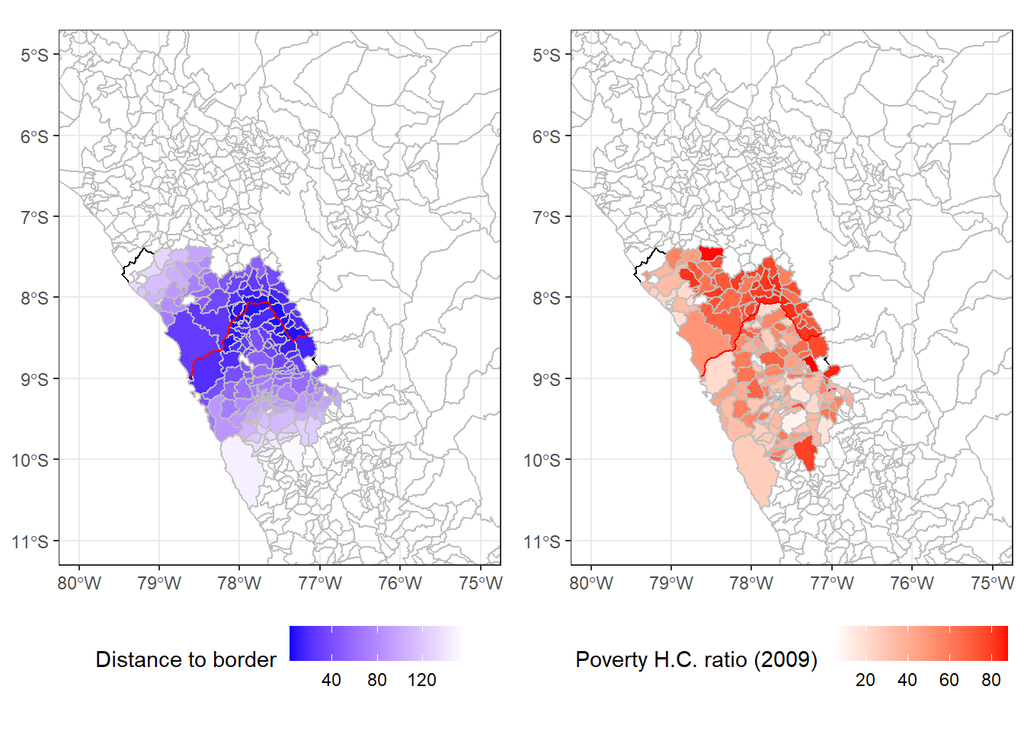

```r
# RV map
map_rv <- ggplot() +
  geom_sf(data=ds, color="grey", fill=NA) +
  geom_sf(data=az3, color="black", fill=NA) +
  geom_sf(data=dat, color="grey", aes(fill=core13_dist)) +
  geom_sf(data=border, color="red") +
  coord_sf(xlim=c(-80, -75), ylim=c(-5,-11)) +
  scale_fill_gradient(name="Distance to border", low="blue", high="white") +
  theme_bw() + theme(legend.position="bottom")

# Outcome map
map_out <- ggplot() +
  geom_sf(data=ds, color="grey", fill=NA) +
  geom_sf(data=az3, color="black", fill=NA) +
  geom_sf(data=dat, color="grey", aes(fill=fgt0)) +
  geom_sf(data=border, color="red") +
  coord_sf(xlim=c(-80, -75), ylim=c(-5,-11)) +
  scale_fill_gradient(name="Poverty H.C. ratio (2009)", low="white", high="red") +
  theme_bw() + theme(legend.position="bottom")

ggarrange(map_rv, map_out, align="h", nrow=1)
```

# RDD analysis

We can now move to the estimation part. Before, we do some further data preparation.

```r
## Rescale RV (negative for control group)
dat <- dat %>% mutate(dist=treat*core13_dist + (1-treat)*(-1*core13_dist))

## Create the border FE
dat <- dat %>% mutate(bfe1=case_when(core13_id==1 ~ 1, TRUE ~ 0),
                      bfe2=case_when(core13_id==2 ~ 1, TRUE ~ 0),
                      bfe3=case_when(core13_id==3 ~ 1, TRUE ~ 0))
```

We begin with a binning plot of our outcome against the RV and the cutoff, to check for visual evidence of discontinuities. We use the “mimicking variance” method and a linear global approximation for simplicity.

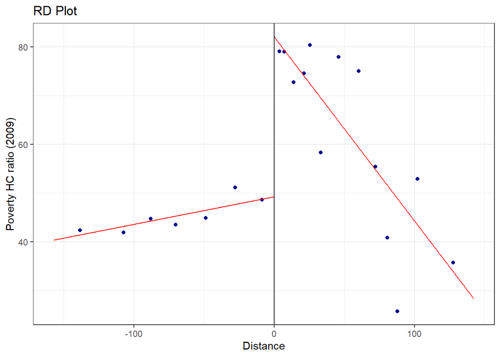

```r
##### RD plot #####
rdplot(y=dat$fgt0, x=dat$dist, binselect="qsmv", x.label="Distance", y.label="Poverty HC ratio (2009)", p=1)
```

As a first estimation approach, we use the one employed by the authors. They estimate simple OLS regressions with manually-selected bandwidth, and repeat the estimation for a grid of BW values. Here for the example, we pick just one BW.

We run different specifications, with and without covariates, and use Conley standard errors to account for spatial correlation. Conley SE are also implemented in the `fixest` package.

```r
####### Estimation 1: LM with hand-selected BW #####
bw_manual <- 50

# Simple difference in means
rd1 <- feols(fgt0 ~ treat, vcov="hetero", data=subset(dat, abs(dist)<bw_manual))

# "Traditional" interacted version
rd2 <- feols(fgt0 ~ treat*dist, vcov="hetero", data=subset(dat, abs(dist)<bw_manual))

# Interacted version + controls
rd3 <- feols(fgt0 ~ treat*dist + elev + slope + icult_land_maj +
               total_road_1973 + pop1972_sup_ha,
             vcov="hetero", data=subset(dat, abs(dist)<bw_manual))

# Conley SE to account for spatial correlation
rd4 <- feols(fgt0 ~ treat*dist, vcov=vcov_conley(lat="y_coord", lon="x_coord", cutoff=50),
             data=subset(dat, abs(dist)<bw_manual))


etable(list(rd1, rd2, rd3, rd4), keep = c("treat"))
```

```
##                          model 1          model 2          model 3
## Dependent Var.:             fgt0             fgt0             fgt0
##
## treat           26.49*** (3.056) 29.22*** (5.783) 29.96*** (6.291)
## treat x dist                     -0.2500 (0.2267) -0.1754 (0.2844)
## _______________ ________________ ________________ ________________
## S.E. type       Heterosked.-rob. Heterosked.-rob. Heterosked.-rob.
## Observations                  75               75               75
## R2                       0.42074          0.42758          0.46717
## Adj. R2                  0.41280          0.40340          0.40259
##                          model 4
## Dependent Var.:             fgt0
##
## treat           29.22*** (3.178)
## treat x dist    -0.2500 (0.1525)
## _______________ ________________
## S.E. type          Conley (50km)
## Observations                  75
## R2                       0.42758
## Adj. R2                  0.40340
```

The second approach is to use `rdrobust`. In this way we select an MSE-optimal bandwidth and use kernel weighting for our local linear regressions.

Unfortunately, `rdrobust` does not allow for spatially correlated SE.

```r
##### Estimation 2: RDrobust with optimal BW #####
rdr1 <- rdrobust(y=dat$fgt0, x=dat$dist, p=1, kernel="triangular", bwselect="mserd", all=T)

summary(rdr1)
```

```
## Call: rdrobust
##
## Number of Obs.                  180
## BW type                       mserd
## Kernel                   Triangular
## VCE method                       NN
##
## Number of Obs.                  128           52
## Eff. Number of Obs.              29           21
## Order est. (p)                    1            1
## Order bias  (q)                   2            2
## BW est. (h)                  28.127       28.127
## BW bias (b)                  48.718       48.718
## rho (h/b)                     0.577        0.577
## Unique Obs.                     128           52
##
## =============================================================================
##         Method     Coef. Std. Err.         z     P>|z|      [ 95% C.I. ]
## =============================================================================
##   Conventional    34.113     8.328     4.096     0.000    [17.789 , 50.436]
## Bias-Corrected    37.177     8.328     4.464     0.000    [20.853 , 53.500]
##         Robust    37.177    10.227     3.635     0.000    [17.133 , 57.220]
## =============================================================================
```

Finally, let’s address the issue of geographic heterogeneity. Keele and Titiunik (2015) discuss how simple GRDD with perpendicular distances to the boundary may result in comparing units that are actually **far** from each other. This can become a problem of unobserved heterogeneity.

We use two approaches. One, employed by the authors, is to use border segment FE to compare only units close to each other. The other, proposed by Keele and Titiunik (2015) is to estimate the LATE geographic frontier by using a grid of points over the boundary.

In order to use segment FE we just enter them as covariates.

```r
##### Spatial het. 1: segment FE #####
rdr2 <- rdrobust(y=dat$fgt0, x=dat$dist, covs=cbind(dat$bfe1, dat$bfe2, dat$bfe3), p=1, kernel="triangular", bwselect="mserd", all=T)

summary(rdr2)
```

```
## Call: rdrobust
##
## Number of Obs.                  180
## BW type                       mserd
## Kernel                   Triangular
## VCE method                       NN
##
## Number of Obs.                  128           52
## Eff. Number of Obs.              32           22
## Order est. (p)                    1            1
## Order bias  (q)                   2            2
## BW est. (h)                  31.625       31.625
## BW bias (b)                  52.734       52.734
## rho (h/b)                     0.600        0.600
## Unique Obs.                     128           52
##
## =============================================================================
##         Method     Coef. Std. Err.         z     P>|z|      [ 95% C.I. ]
## =============================================================================
##   Conventional    32.253     7.615     4.235     0.000    [17.327 , 47.180]
## Bias-Corrected    34.766     7.615     4.565     0.000    [19.840 , 49.692]
##         Robust    34.766     9.374     3.709     0.000    [16.393 , 53.139]
## =============================================================================
```

As to the second approach, for simplicity we just use three randomly selected points along the frontier.

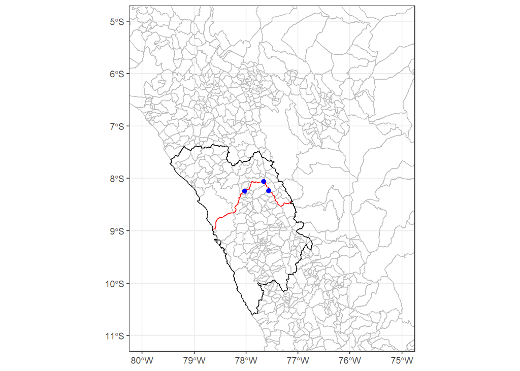

```r
##### Spatial het. 2: point distance #####

## Sample the points
set.seed(1)
points <- st_sample(border, size=3)

## Where are they?
ggplot() +
  geom_sf(data=ds, color="grey", fill=NA) +
  geom_sf(data=az3, color="black", fill=NA) +
  geom_sf(data=border, color="red") +
  geom_sf(data=points, color="blue", size=2, shape=19) +
  coord_sf(xlim=c(-80, -75), ylim=c(-5,-11)) +
  theme_bw()
```

For each district, we compute new RVs which are the distance from each of these points. To do so, we extract the centroids of the polygons and work with them separately.

```r
centroids <- dat %>%
  # convert the data from the existing geometry (polygon) to numbers
  st_drop_geometry %>%
  select(c(codeconc, x_coord, y_coord))

# Convert the centroids into another geometry: points
centroids <- st_as_sf(centroids, coords=c("x_coord", "y_coord"),
                      crs="+proj=longlat")

# Give the same CRS of the other objects
centroids <- st_transform(centroids, crs=st_crs(ds))

## Success?
st_crs(centroids)==st_crs(ds)
```

```
## [1] TRUE
```

```r
# For each centroid, compute the minimum distance to each of the points
# First turn object into set of single points
points <- points %>%
  st_cast(to="POINT") %>%
  st_as_sf()

# Compute distances and convert to km
centroids <- centroids %>%
  mutate(distp1=st_distance(geometry, points[1,])/1000,
         distp2=st_distance(geometry, points[2,])/1000,
         distp3=st_distance(geometry, points[3,])/1000)


# Merge back the distances with data
dists <- centroids %>% st_drop_geometry() %>% select(c(codeconc, starts_with("distp")))

dat <- left_join(dat, dists, by="codeconc")

# Re-scale all the new RVs
rescale <- function(x){
  x <- dat$treat*x + (1-dat$treat)*{-1*x}
  x
}
dat <- dat %>% mutate(across(starts_with("distp"), rescale))
```

Finally, we do the RDD on each point separately.

```r
rdp1 <- rdrobust(y=dat$fgt0, x=dat$distp1, p=1, kernel="triangular", bwselect="mserd", all=T)

rdp2 <- rdrobust(y=dat$fgt0, x=dat$distp2, p=1, kernel="triangular", bwselect="mserd", all=T)

rdp3 <- rdrobust(y=dat$fgt0, x=dat$distp3, p=1, kernel="triangular", bwselect="mserd", all=T)

# Results
out <- do.call("rbind", lapply(list(rdp1, rdp2, rdp3), function(x) cbind(x$coef["Robust",], x$se["Robust",]))) %>% as.data.frame()
colnames(out) <- c("Coeff", "SE")

out
```

```
##       Coeff       SE
## 1 40.364520 29.23933
## 2 99.638110 76.42173
## 3 -1.777433 35.13635
```